# EDA Budweiser dataset

## bar plot of breweries by state

[figure not shown]

# Above Code: We ran code to group and count breweries by state. [See State Count csv file](https://github.com/jjsmu/group16/blob/main/state_counts.csv)

# PART II

# 2. Merge beer data with the breweries data. Print the first 6 observations and the last six observations to check the merged file. (RMD only, this does not need to be included in the presentation or the deck.)

# First 6 Observations

```r
# full merge beer and breweries data frames
BEER_AND_BREWERIES <- merge(BEERS, BREWERIES, by.x = "Brewery_id", by.y = "Brew_ID", all = TRUE) %>%
  rename(Beer = Name.x, Brewery = Name.y)
# view complete table
View(BEER_AND_BREWERIES)
# print the first 6 observations
print(head(BEER_AND_BREWERIES, n = 6))
```

```
##   Brewery_id          Beer Beer_ID   ABV IBU
## 1          1  Get Together    2692 0.045  50
## 2          1 Maggie's Leap    2691 0.049  26
## 3          1    Wall's End    2690 0.048  19
## 4          1       Pumpion    2689 0.060  38
## 5          1    Stronghold    2688 0.060  25
## 6          1   Parapet ESB    2687 0.056  47
##                                 Style Ounces            Brewery        City
## 1                        American IPA     16 NorthGate Brewing  Minneapolis
## 2                  Milk / Sweet Stout     16 NorthGate Brewing  Minneapolis
## 3                   English Brown Ale     16 NorthGate Brewing  Minneapolis
## 4                         Pumpkin Ale     16 NorthGate Brewing  Minneapolis
## 5                     American Porter     16 NorthGate Brewing  Minneapolis
## 6 Extra Special / Strong Bitter (ESB)     16 NorthGate Brewing  Minneapolis
##   State
## 1    MN
## 2    MN
## 3    MN
## 4    MN
## 5    MN
## 6    MN
```

```r
# print the last 6 observations
print(tail(BEER_AND_BREWERIES, n = 6))
```

```
##      Brewery_id                      Beer Beer_ID   ABV IBU
## 2405        556             Pilsner Ukiah      98 0.055  NA
## 2406        557  Heinnieweisse Weissebier      52 0.049  NA
## 2407        557           Snapperhead IPA      51 0.068  NA
## 2408        557         Moo Thunder Stout      50 0.049  NA
## 2409        557         Porkslap Pale Ale      49 0.043  NA
## 2410        558 Urban Wilderness Pale Ale      30 0.049  NA
##                        Style Ounces                       Brewery          City
## 2405         German Pilsener     12         Ukiah Brewing Company         Ukiah
## 2406              Hefeweizen     12       Butternuts Beer and Ale Garrattsville
## 2407            American IPA     12       Butternuts Beer and Ale Garrattsville
## 2408      Milk / Sweet Stout     12       Butternuts Beer and Ale Garrattsville
## 2409 American Pale Ale (APA)     12       Butternuts Beer and Ale Garrattsville
## 2410        English Pale Ale     12 Sleeping Lady Brewing Company     Anchorage
##      State
## 2405    CA
## 2406    NY
## 2407    NY
## 2408    NY
## 2409    NY
## 2410    AK
```

# Above Code: we checked the merged datasets

# PART III

# 3. Address the missing values in each column.

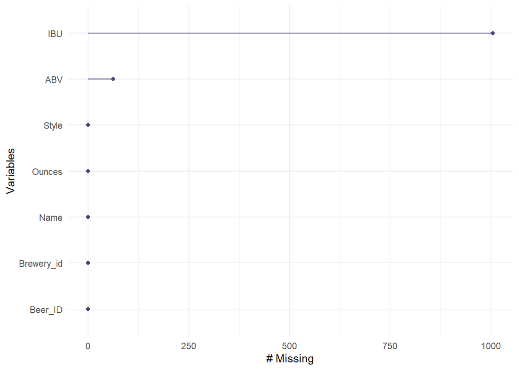

```r
# tidy data
library(naniar)

# plot missing variables
gg_miss_var(BEERS) # IBU, ABV Missing
```

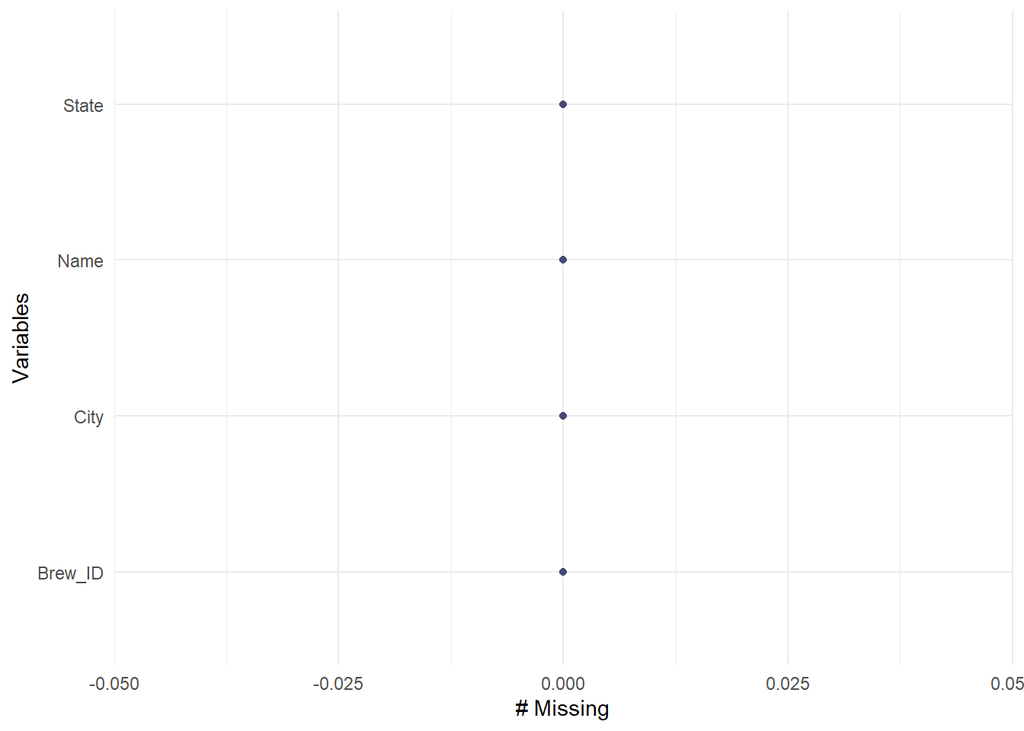

```r
gg_miss_var(BREWERIES)
```

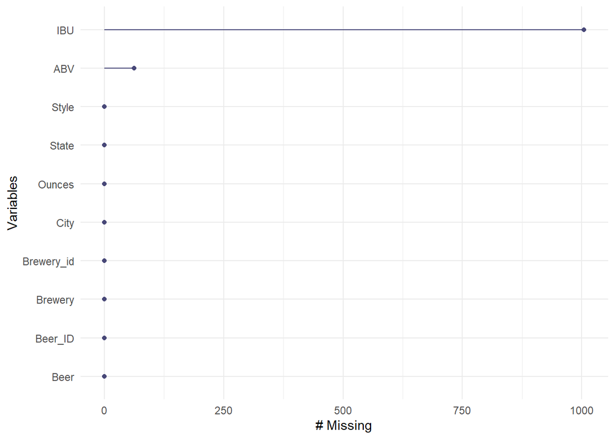

```r
gg_miss_var(BEER_AND_BREWERIES)
```

```r
# test for NA values
sum(is.na(BEERS$ABV)) # missing 62 values
```

```
## [1] 62
```

```r
sum(is.na(BEERS$IBU)) # missing 1005 values
```

```
## [1] 1005
```

```r
sum(is.na(BEER_AND_BREWERIES)) # missing 1067 values
```

```
## [1] 1067
```

```r
# store index of rows containing NA
missing_index <- which(is.na(BEER_AND_BREWERIES))
missing_index
```

[output not shown]

[output cut: 74 more lines]

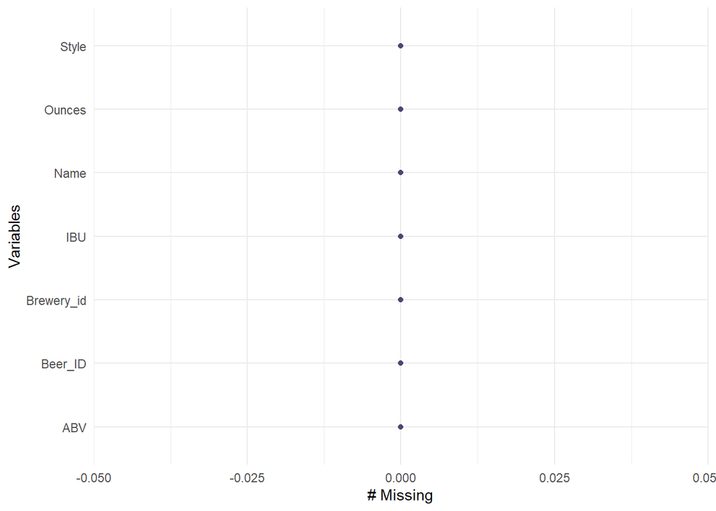

```r
# test the function complete.cases() on gg_miss_var
gg_miss_var(BEERS[complete.cases(BEERS$IBU, BEERS$ABV), ])
```

```r
# replace missing NA values with new value
# BEERS <- BEERS[complete.cases(BEERS$IBU, BEERS$ABV), ]

# NOTE: South Dakota IBU is NA for all, missing IBU data
```

# Above Code: Adressed missing values in datasets. See Codebook for additional information

# PART IV

# 4. Compute the median alcohol content and international bitterness unit for each state. Plot a bar chart to compare.

```r
# filter and summarize ABV by state
median_by_state <- BEER_AND_BREWERIES %>%
  group_by(State) %>%
  #filter(!is.na(ABV) & !is.na(IBU)) %>%
  summarize(median_ABV = median(ABV, na.rm = TRUE), median_IBU = median(IBU, na.rm = TRUE))
(median_by_state)
```

```
## # A tibble: 51 × 3
##    State median_ABV median_IBU
##    <chr>      <dbl>      <dbl>
##  1 " AK"     0.056        46
##  2 " AL"     0.06         43
##  3 " AR"     0.052        39
##  4 " AZ"     0.055        20.5
##  5 " CA"     0.058        42
##  6 " CO"     0.0605       40
##  7 " CT"     0.06         29
##  8 " DC"     0.0625       47.5
##  9 " DE"     0.055        52
## 10 " FL"     0.057        55
## # ℹ 41 more rows
```

```r
# store sample size
total_states <- count(median_by_state)
total_states
```

```
## # A tibble: 1 × 1
##       n
##   <int>
## 1    51
```

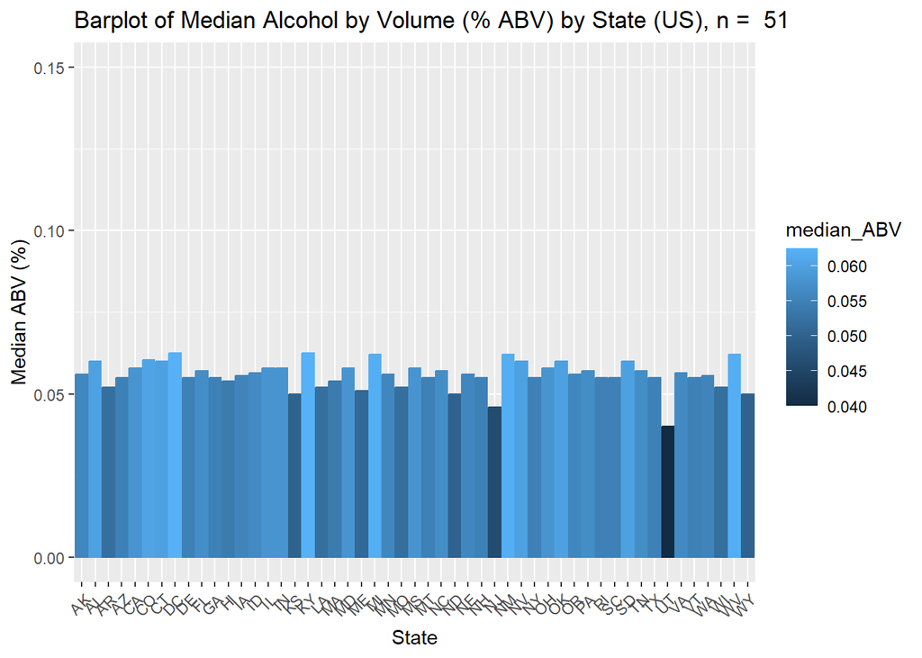

```r
# bar plot median ABV
barplot_median_abv <- median_by_state %>%
  ggplot(aes(State, median_ABV, color = median_ABV, fill = median_ABV)) +
  geom_bar(stat = "identity") +
  ggtitle(paste("Barplot of Median Alcohol by Volume (% ABV) by State (US), n = ", total_states)) +
  xlab("State") + ylab("Median ABV (%)") + ylim(0, 0.15) +
  theme(axis.text.x = element_text(angle = 45, hjust = 1))
barplot_median_abv
```

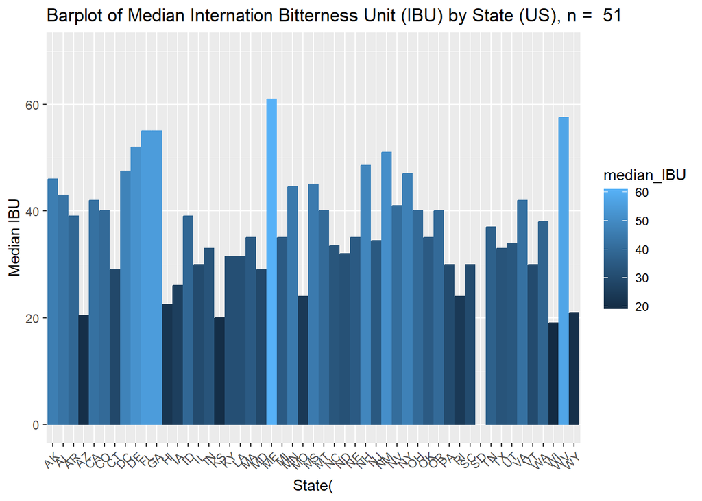

```r
# bar plot median IBU
barplot_median_ibu <- median_by_state %>%
  ggplot(aes(State, median_IBU, color = median_IBU, fill = median_IBU)) +
  geom_bar(stat = "identity") +
  ggtitle(paste("Barplot of Median Internation Bitterness Unit (IBU) by State (US), n = ", total_states)) +
  xlab("State(") + ylab("Median IBU") + ylim(0, 70) +
  theme(axis.text.x = element_text(angle = 45, hjust = 1))
barplot_median_ibu
```

# PART V #5. Which state has the maximum alcoholic (ABV) beer? Which state has the most bitter (IBU) beer?

```r
# group filter and summarize max abv and ibu values
max_by_state <- BEER_AND_BREWERIES %>%
  group_by(State) %>%
  #filter(!is.na(ABV) & !is.na(IBU)) %>%
  summarize(max_ABV = max(ABV, na.rm = TRUE), max_IBU = max(IBU, na.rm = TRUE))
max_by_state
```

```
## # A tibble: 51 × 3
##    State max_ABV max_IBU
##    <chr>   <dbl>   <dbl>
##  1 " AK"   0.068      71
##  2 " AL"   0.093     103
##  3 " AR"   0.061      39
##  4 " AZ"   0.095      99
##  5 " CA"   0.099     115
##  6 " CO"   0.128     104
##  7 " CT"   0.09       85
##  8 " DC"   0.092     115
##  9 " DE"   0.055      52
## 10 " FL"   0.082      82
## # ℹ 41 more rows
```

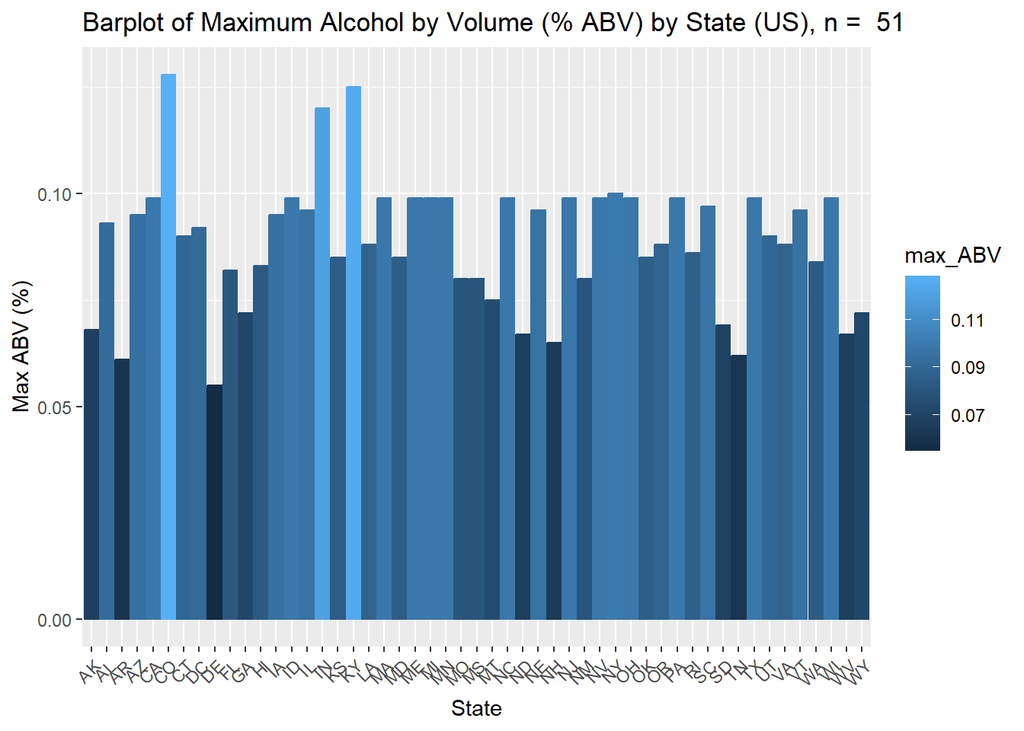

```r
# bar plot max ABV
barplot_max_abv <- max_by_state %>%
  ggplot(aes(State, max_ABV, color = max_ABV, fill = max_ABV)) +
  geom_bar(stat = "identity") +
  ggtitle(paste("Barplot of Maximum Alcohol by Volume (% ABV) by State (US), n = ", total_states)) +
  xlab("State") + ylab("Max ABV (%)") +
  theme(axis.text.x = element_text(angle = 45, hjust = 1))
barplot_max_abv
```

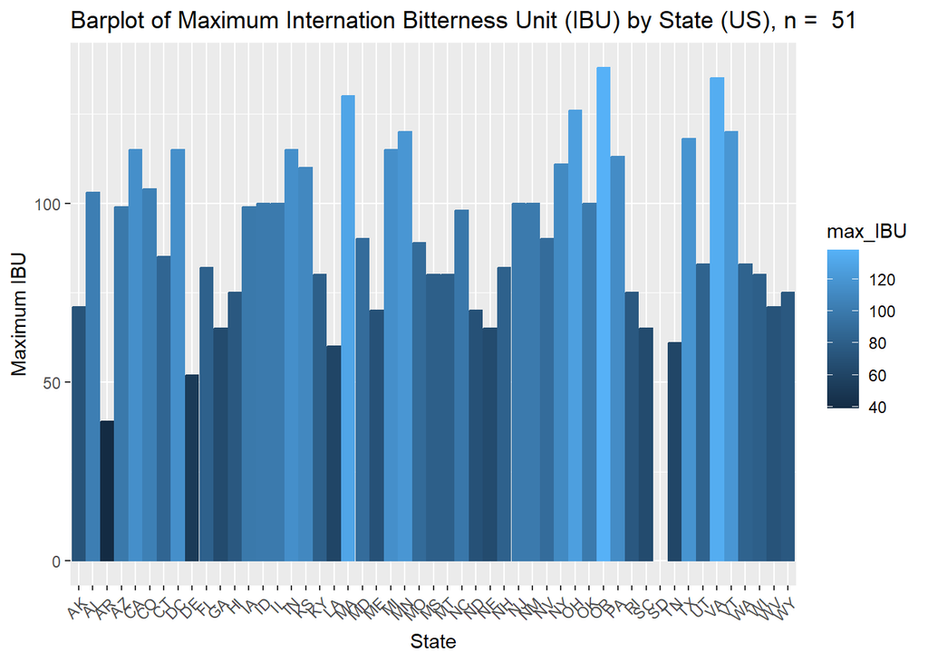

```r
# bar plot max IBU
barplot_max_ibu <- max_by_state %>%
  ggplot(aes(State, max_IBU, color = max_IBU, fill = max_IBU)) +
  geom_bar(stat = "identity") +
  ggtitle(paste("Barplot of Maximum Internation Bitterness Unit (IBU) by State (US), n = ", total_states)) +
  xlab("State") + ylab("Maximum IBU") +
  theme(axis.text.x = element_text(angle = 45, hjust = 1))
barplot_max_ibu
```

```r
# console output max abv and ibu values
max(max_by_state$max_ABV)
```

```
## [1] 0.128
```

```r
max(max_by_state$max_IBU)
```

```
## [1] 138
```

```r
# store max abv and ibu index
max_abv <- which.max(max_by_state$max_ABV)
max_ibu <- which.max(max_by_state$max_IBU)

# console output max abv and ibu pointers
max_abv
```

```
## [1] 6
```

```r
max_ibu
```

```
## [1] 38
```

```r
# find max abv and ibu state by index
max_abv_state <- max_by_state$State[max_abv]
max_ibu_state <- max_by_state$State[max_ibu]

# console output max abv and ibu
max_abv_state # "CO"
```

```
## [1] " CO"
```

```r
max_ibu_state # "OR"
```

```
## [1] " OR"
```

```r
# import map libraries
library(maps)
library(mapproj)

# merge max and med abv and ibu
max_med_abv_ibu <- merge(max_by_state, median_by_state, by = "State", all = TRUE)
max_med_abv_ibu
```

```
##    State max_ABV max_IBU median_ABV median_IBU
## 1     AK   0.068      71     0.0560       46.0
## 2     AL   0.093     103     0.0600       43.0
## 3     AR   0.061      39     0.0520       39.0
## 4     AZ   0.095      99     0.0550       20.5
## 5     CA   0.099     115     0.0580       42.0
## 6     CO   0.128     104     0.0605       40.0
## 7     CT   0.090      85     0.0600       29.0
## 8     DC   0.092     115     0.0625       47.5
## 9     DE   0.055      52     0.0550       52.0
## 10    FL   0.082      82     0.0570       55.0
## 11    GA   0.072      65     0.0550       55.0
## 12    HI   0.083      75     0.0540       22.5
## 13    IA   0.095      99     0.0555       26.0
## 14    ID   0.099     100     0.0565       39.0
```

[output cut: 37 more lines]

```r
# merge brewery count with max and med abv and ibu
breweries_map_data <- merge(max_med_abv_ibu, breweries_by_state, by = "State")
#colnames(breweries_map_data)[1] = "abb"
breweries_map_data$State <- trimws(breweries_map_data$State)
breweries_map_data
```

```
##    State max_ABV max_IBU median_ABV median_IBU Count
## 1     AK   0.068      71     0.0560       46.0     7
## 2     AL   0.093     103     0.0600       43.0     3
## 3     AR   0.061      39     0.0520       39.0     2
## 4     AZ   0.095      99     0.0550       20.5    11
## 5     CA   0.099     115     0.0580       42.0    39
## 6     CO   0.128     104     0.0605       40.0    47
## 7     CT   0.090      85     0.0600       29.0     8
## 8     DC   0.092     115     0.0625       47.5     1
## 9     DE   0.055      52     0.0550       52.0     2
## 10    FL   0.082      82     0.0570       55.0    15
## 11    GA   0.072      65     0.0550       55.0     7
## 12    HI   0.083      75     0.0540       22.5     4
## 13    IA   0.095      99     0.0555       26.0     5
## 14    ID   0.099     100     0.0565       39.0     5
```

[output cut: 37 more lines]

```r
# store state in lookup dataframe
lookup = data.frame(State = state.abb, region = state.name) #makes a data frame with State name and abbreviation.
lookup <- bind_rows(lookup, data.frame(State = "DC", region = "Washington DC")) # Add missing row
lookup <- lookup %>% arrange(lookup$State)
lookup$region <- tolower(lookup$region)
#lookup

# create state map data frame
us_states <- map_data("state")
us_states$subregion <- NULL
#us_states

# Found the bug! Blank space prevents merging, use trimws function
unique(breweries_map_data$State)
```

```
##  [1] "AK" "AL" "AR" "AZ" "CA" "CO" "CT" "DC" "DE" "FL" "GA" "HI" "IA" "ID" "IL"
## [16] "IN" "KS" "KY" "LA" "MA" "MD" "ME" "MI" "MN" "MO" "MS" "MT" "NC" "ND" "NE"
## [31] "NH" "NJ" "NM" "NV" "NY" "OH" "OK" "OR" "PA" "RI" "SC" "SD" "TN" "TX" "UT"
## [46] "VA" "VT" "WA" "WI" "WV" "WY"
```

```r
unique(lookup$State)
```

```
##  [1] "AK" "AL" "AR" "AZ" "CA" "CO" "CT" "DC" "DE" "FL" "GA" "HI" "IA" "ID" "IL"
## [16] "IN" "KS" "KY" "LA" "MA" "MD" "ME" "MI" "MN" "MO" "MS" "MT" "NC" "ND" "NE"
## [31] "NH" "NJ" "NM" "NV" "NY" "OH" "OK" "OR" "PA" "RI" "SC" "SD" "TN" "TX" "UT"
## [46] "VA" "VT" "WA" "WI" "WV" "WY"
```

```r
# merge breweries and lookup data
breweries_lookup <- merge(breweries_map_data, lookup, by = "State")
breweries_lookup
```

```
##    State max_ABV max_IBU median_ABV median_IBU Count         region
## 1     AK   0.068      71     0.0560       46.0     7         alaska
## 2     AL   0.093     103     0.0600       43.0     3        alabama
## 3     AR   0.061      39     0.0520       39.0     2       arkansas
## 4     AZ   0.095      99     0.0550       20.5    11        arizona
## 5     CA   0.099     115     0.0580       42.0    39     california
## 6     CO   0.128     104     0.0605       40.0    47       colorado
## 7     CT   0.090      85     0.0600       29.0     8    connecticut
## 8     DC   0.092     115     0.0625       47.5     1  washington dc
## 9     DE   0.055      52     0.0550       52.0     2       delaware
## 10    FL   0.082      82     0.0570       55.0    15        florida
## 11    GA   0.072      65     0.0550       55.0     7        georgia
## 12    HI   0.083      75     0.0540       22.5     4         hawaii
## 13    IA   0.095      99     0.0555       26.0     5           iowa
## 14    ID   0.099     100     0.0565       39.0     5          idaho
```

[output cut: 37 more lines]

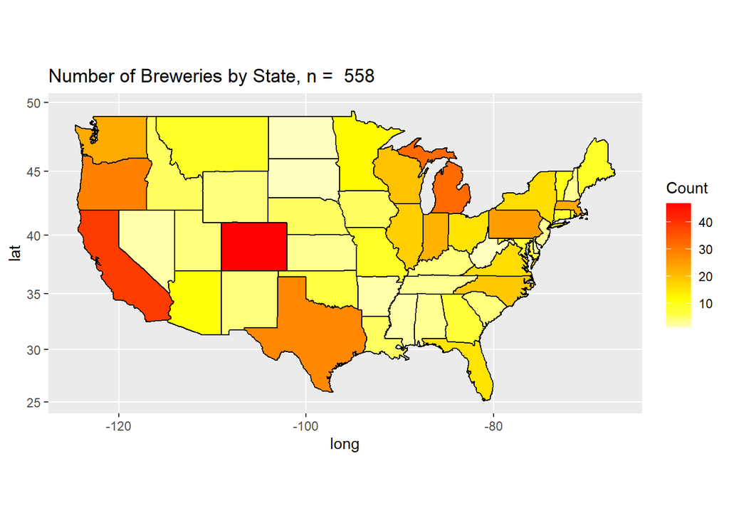

```r
# merge breweries lookup and us states by region
map.df <- merge(breweries_lookup, us_states, by = "region", all.x = T)
map.df <- map.df[order(map.df$order),] # arrange order desc, fix polygon clipping
#map.df

# plot the map data
breweries_heat_map <- map.df %>% ggplot(aes(x=long,y=lat,group=group))+
  geom_polygon(aes(fill = Count))+
  geom_path() +
  scale_fill_gradientn(colours=rev(heat.colors(10)),na.value="grey90")+ggtitle(paste("Number of Breweries by State, n = ", total_breweries)) +
coord_map()
breweries_heat_map
```

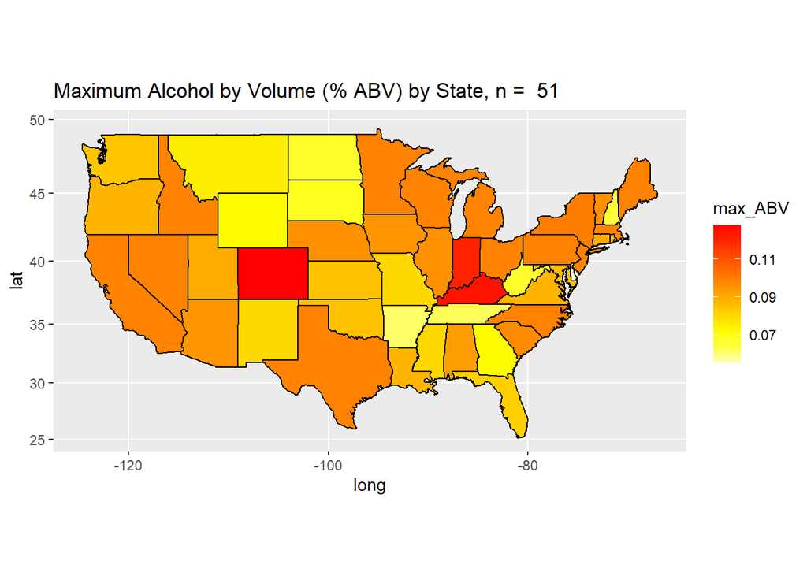

```r
# max abv heat map
max_abv_heat_map <- map.df %>% ggplot(aes(x = long, y = lat, group = group)) +
  geom_polygon(aes(fill = max_ABV)) + geom_path() + scale_fill_gradientn(colors = rev(heat.colors(10)), na.value = "grey90") +
  ggtitle(paste("Maximum Alcohol by Volume (% ABV) by State, n = ", total_states)) +
  coord_map()
max_abv_heat_map
```

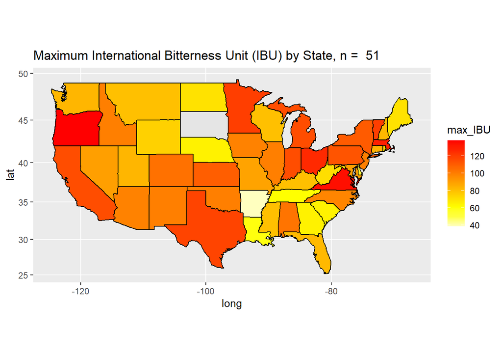

```r
# max ibu heat map
max_ibu_heat_map <- map.df %>% ggplot(aes(x = long, y = lat, group = group)) +
  geom_polygon(aes(fill = max_IBU)) + geom_path() + scale_fill_gradientn(colors = rev(heat.colors(10)), na.value = "grey90") +
  ggtitle(paste("Maximum International Bitterness Unit (IBU) by State, n = ", total_states)) +
  coord_map()
max_ibu_heat_map
```

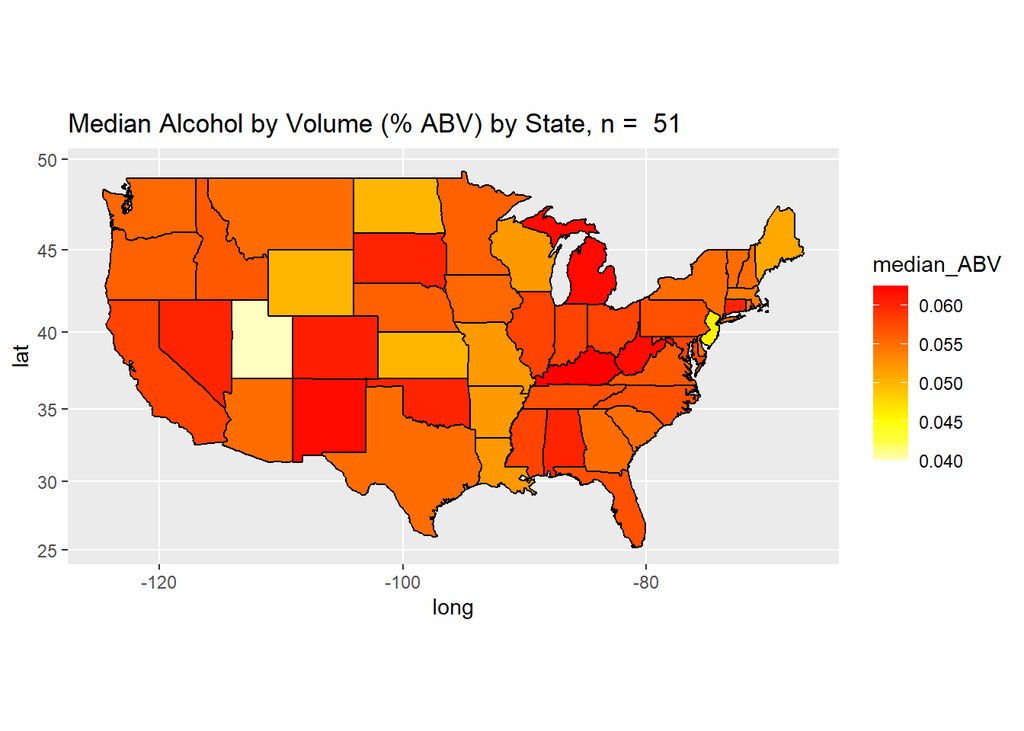

```r
# median abv heat map
med_abv_heat_map <- map.df %>% ggplot(aes(x = long, y = lat, group = group)) +
  geom_polygon(aes(fill = median_ABV)) + geom_path() + scale_fill_gradientn(colors = rev(heat.colors(10)), na.value = "grey90") +
  ggtitle(paste("Median Alcohol by Volume (% ABV) by State, n = ", total_states)) +
  coord_map()
med_abv_heat_map
```

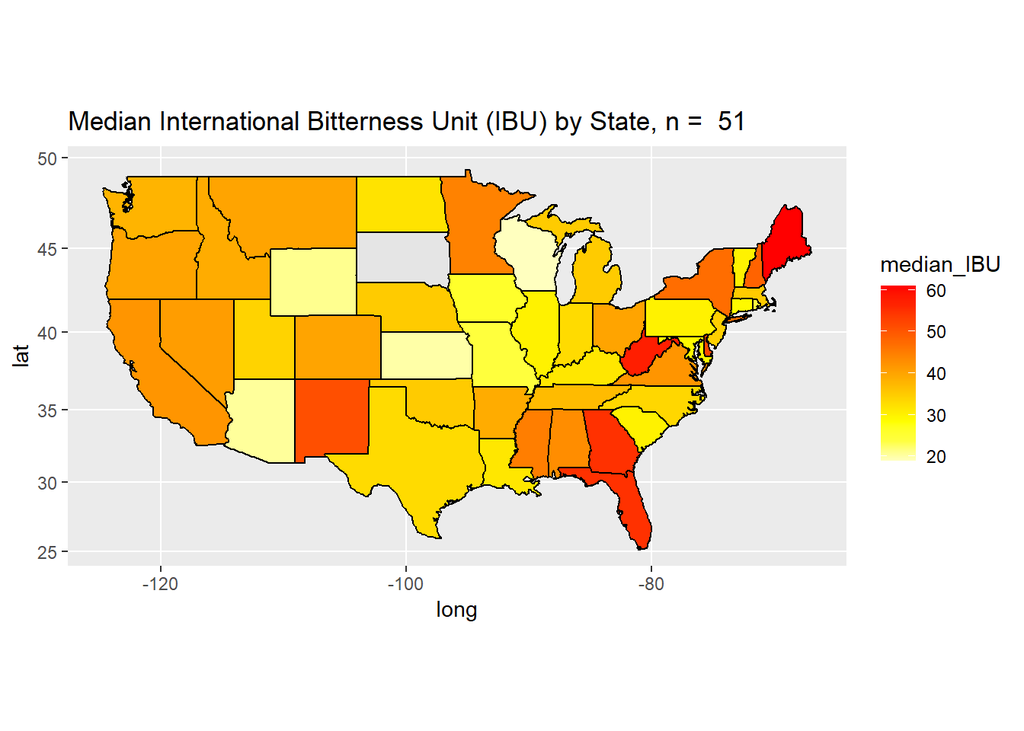

```r
# median ibu heat map
med_ibu_heat_map <- map.df %>% ggplot(aes(x = long, y = lat, group = group)) +
  geom_polygon(aes(fill = median_IBU)) + geom_path() + scale_fill_gradientn(colors = rev(heat.colors(10)), na.value = "grey90") +
  ggtitle(paste("Median International Bitterness Unit (IBU) by State, n = ", total_states)) +
  coord_map()
med_ibu_heat_map
```

```r
# string_r, which, grepl
# TODO search for keywords 'Ale', 'Pilsner', 'Stout'
```

# Above code: CO has the maximum alcoholic (ABV) beer. OR has the most bitter (IBU) beer

# PART VI

# 6. Comment on the summary statistics and distribution of the ABV variable.

```r
# Comments:
summary(BEER_AND_BREWERIES)
```

```
##    Brewery_id        Beer              Beer_ID            ABV
##  Min.   :  1.0   Length:2410        Min.   :   1.0   Min.   :0.00100
##  1st Qu.: 94.0   Class :character   1st Qu.: 808.2   1st Qu.:0.05000
##  Median :206.0   Mode  :character   Median :1453.5   Median :0.05600
##  Mean   :232.7                      Mean   :1431.1   Mean   :0.05977
##  3rd Qu.:367.0                      3rd Qu.:2075.8   3rd Qu.:0.06700
##  Max.   :558.0                      Max.   :2692.0   Max.   :0.12800
##                                                      NA's   :62
##       IBU            Style               Ounces        Brewery
##  Min.   :  4.00   Length:2410        Min.   : 8.40   Length:2410
##  1st Qu.: 21.00   Class :character   1st Qu.:12.00   Class :character
##  Median : 35.00   Mode  :character   Median :12.00   Mode  :character
##  Mean   : 42.71                      Mean   :13.59
##  3rd Qu.: 64.00                      3rd Qu.:16.00
##  Max.   :138.00                      Max.   :32.00
##  NA's   :1005
##      City              State
##  Length:2410        Length:2410
##  Class :character   Class :character
##  Mode  :character   Mode  :character
##
##
##
##
```

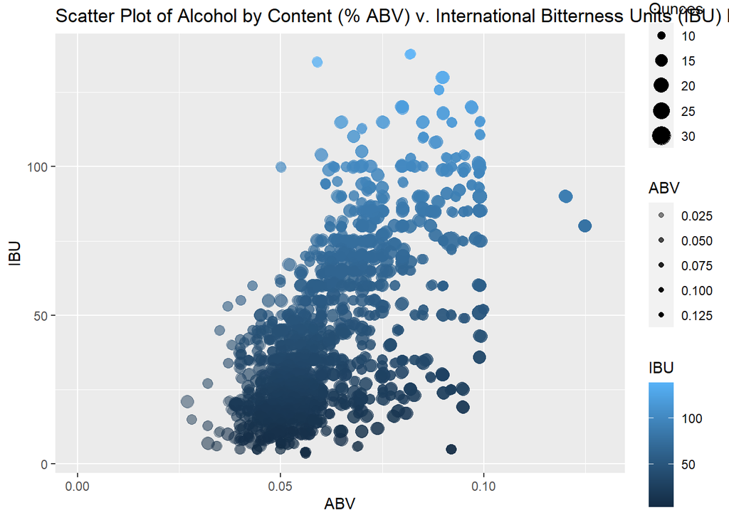

```r
plot_breweries <- BEER_AND_BREWERIES %>%
  ggplot(aes(ABV, IBU, alpha = ABV, size = Ounces, color = IBU), na.rm = TRUE) + geom_point() + geom_jitter() +
  ggtitle(paste("Scatter Plot of Alcohol by Content (% ABV) v. International Bitterness Units (IBU) by State (US), n = ", total_beers)) + xlab("ABV") + ylab("IBU")
plot_breweries
```

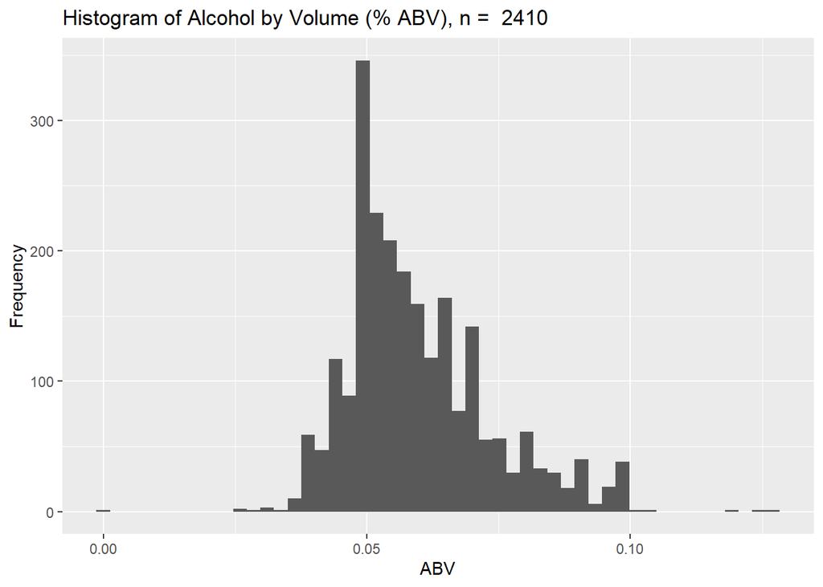

```r
total_beers <- count(BEER_AND_BREWERIES)
hist_abv <- BEER_AND_BREWERIES %>%
  select(Beer, ABV, Style, Ounces, Brewery) %>%
  #filter(!is.na(ABV)) %>%
  ggplot(aes(ABV), na.rm = TRUE) + geom_histogram(stat = "bin", bins = 50) +
  ggtitle(paste("Histogram of Alcohol by Volume (% ABV), n = ", total_beers)) +
  xlab("ABV") + ylab("Frequency")
hist_abv
```

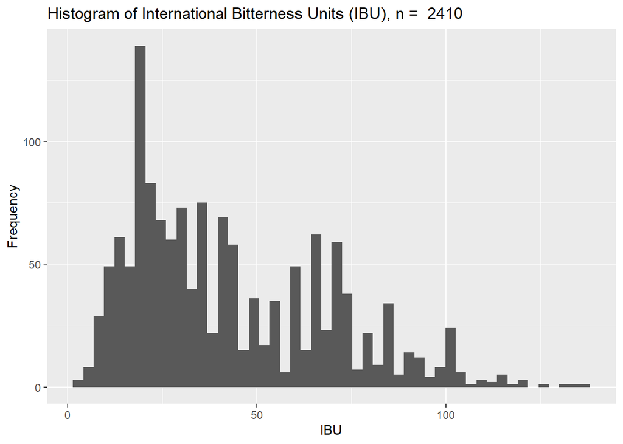

```r
hist_ibu <- BEER_AND_BREWERIES %>%
  select(Beer, IBU, Style, Ounces, Brewery) %>%
  #filter(!is.na(IBU)) %>%
  ggplot(aes(IBU), na.rm = TRUE) + geom_histogram(stat = "bin", bins = 50) +
  ggtitle(paste("Histogram of International Bitterness Units (IBU), n = ", total_beers)) +
  xlab("IBU") + ylab("Frequency")
hist_ibu
```

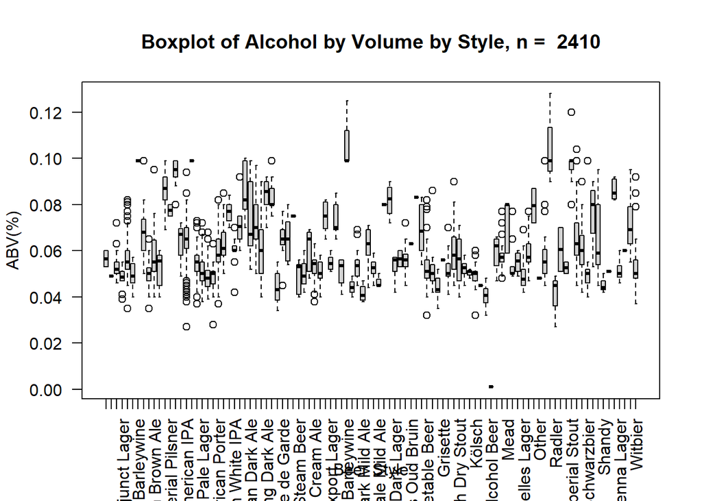

```r
# box plot of ABV by Beer Style
boxplot(BEERS$ABV~BEERS$Style, las = 2, names.arg = BEERS$Style, main = paste("Boxplot of Alcohol by Volume by Style, n = ", length(BEERS$Style)), xlab = "Beer Style", ylab = "ABV(%)")
```

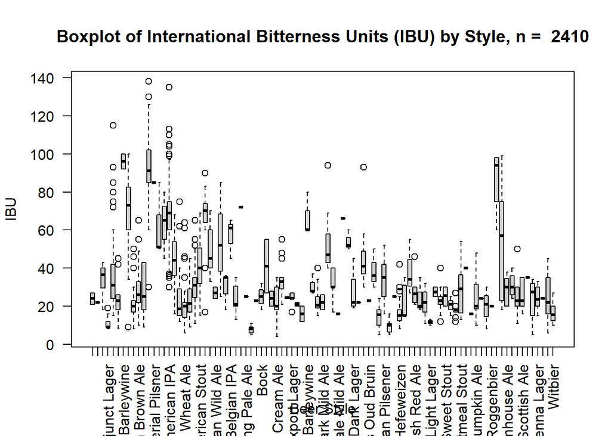

```r
# box plot of IBU by Beer Style
boxplot(BEERS$IBU~BEERS$Style, las = 2, names.arg = BEERS$Style, main = paste("Boxplot of International Bitterness Units (IBU) by Style, n = ", length(BEERS$Style)), xlab = "Beer Style", ylab = "IBU")
```